# eBird Status and Trends Japan Workshop

## Setup

Before working through these examples, complete the [workshop setup instructions](https://docs.google.com/document/d/1M8asSf0xWC06SpLcn-Ff9PD2IfgZ0ghwcZYclyccdrk/edit?usp=sharing) to install the necessary software and R packages, and to gain access to the eBird Status and Trends data products.

After completing the setup instructions load the R packages that we will use for this workshop.

- `ebirdst` is used for downloading and working with eBird Status and Trend data products.
- `dplyr`, `tidyr`, and `ggplot2` are used for data manipulation and plotting.
- `sf` and `terra` are used to work with spatial datasets like those you can access with `ebirdst`.
- `rnaturalearth` gives access to country and state/prefecture boundaries.

```r
library(ebirdst)
library(dplyr)
library(tidyr)
library(ggplot2)
library(sf)
library(terra)
library(rnaturalearth)
```

## Downloading eBird Status Data Products

To download the eBird Status data products you can provide the English common name or scientific name to `ebirdst_download_status()` . For example, to download data for *Delichon dasypus* (Asian House-Martin / イワツバメ) use

```r
ebirdst_download_status("Delichon dasypus")
```

```
Downloading Status Data Products for ashmar1
```

```
Data already exists, use force = TRUE to re-download.
```

The files are downloaded to a folder on your computer specifically for the eBird Status and Trends data products and you can load them into R using functions from `ebirdst`. The relative abundance estimates are provided in raster format with estimates for every cell of a 3 km X 3 km grid. The weekly relative abundance raster has one layer for each week of the year and can be loaded into R using

```r
abd_weekly <- load_raster("Delichon dasypus")
print(abd_weekly)
```

```
class       : SpatRaster
size        : 5562, 11484, 52  (nrow, ncol, nlyr)
resolution  : 3000, 3000  (x, y)
extent      : -17226000, 17226000, -8343000, 8343000  (xmin, xmax, ymin, ymax)
coord. ref. : WGS 84 / Equal Earth Greenwich (EPSG:8857)
source      : ashmar1_abundance_median_3km_2023.tif
names       : 2023-01-04, 2023-01-11, 2023-01-18, 2023-01-25, 2023-02-01, 2023-02-08, ...
min values  :   0.000000,    0.00000,    0.00000,   0.000000,   0.000000,   0.000000, ...
max values  :   3.936424,    5.96906,    7.47692,   8.406252,   9.125364,   6.991024, ...
```

```r
abd_seasonal <- load_raster("Hirundo rustica", period = "seasonal")
print(abd_seasonal)
```

```
class       : SpatRaster
size        : 5562, 11484, 4  (nrow, ncol, nlyr)
resolution  : 3000, 3000  (x, y)
extent      : -17226000, 17226000, -8343000, 8343000  (xmin, xmax, ymin, ymax)
coord. ref. : WGS 84 / Equal Earth Greenwich (EPSG:8857)
source      : barswa_abundance_seasonal_mean_3km_2023.tif
names       : breeding, nonbreeding, prebree~gration, postbre~gration
min values  :   0.0000,       0.000,          0.0000,           0.000
max values  : 183.4646,    2517.578,        720.9156,        7011.301
```

## Migration Chronologies

Migration chronologies chart the change in relative abundance throughout the year for a given region. They can be useful for identifying when a given geography receives the highest intensity of use by a species or group of species. In this example we’ll produce migration chronologies for *Delichon dasypus* in two prefectures: Akita in the north and Fukuoka in the south.

To start, we’ll download boundaries of the two prefectures using `rnaturalearth`. We also need to transform these spatial boundaries to be in the same projection as the relative abundance raster.

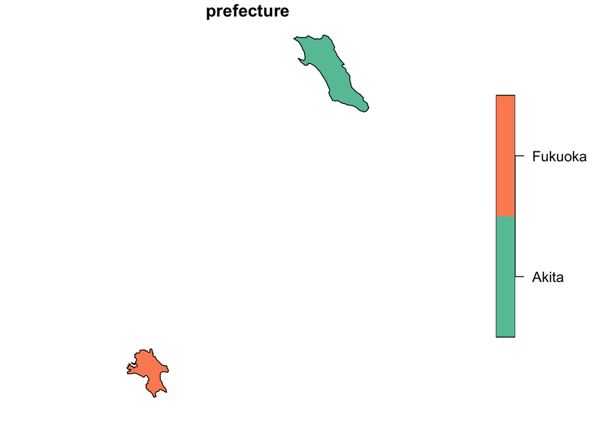

```r
boundaries <- ne_states(country = "Japan") |>
  filter(name %in% c("Akita", "Fukuoka")) |>
  select(prefecture = name) |>
  st_transform(crs = crs(abd_weekly))
plot(boundaries)
```

Next we’ll use the `extract()` function from the `terra` package to find the average relative abundance for each week within each prefecture.

```r
chronology <- extract(abd_weekly, boundaries,
                      fun = "mean", na.rm = TRUE,
                      bind = TRUE, ID = FALSE) |>
  as.data.frame()
```

```r
chronology <- pivot_longer(
  chronology,
  cols = starts_with("X"),
  names_to = "week", values_to = "abd",
  names_transform = \(x) as.Date(x, format = "X%Y.%m.%d")
)
print(chronology)
```

```
# A tibble: 104 × 3
   prefecture week         abd
   <chr>      <date>     <dbl>
 1 Fukuoka    2023-01-04 0.241
 2 Fukuoka    2023-01-11 0.458
 3 Fukuoka    2023-01-18 0.549
 4 Fukuoka    2023-01-25 0.403
 5 Fukuoka    2023-02-01 0.311
 6 Fukuoka    2023-02-08 0.273
 7 Fukuoka    2023-02-15 0.348
 8 Fukuoka    2023-02-22 0.406
 9 Fukuoka    2023-03-01 0.331
10 Fukuoka    2023-03-08 0.345
# ℹ 94 more rows
```

Finally, we can use this data frame to plot a migration chronology.

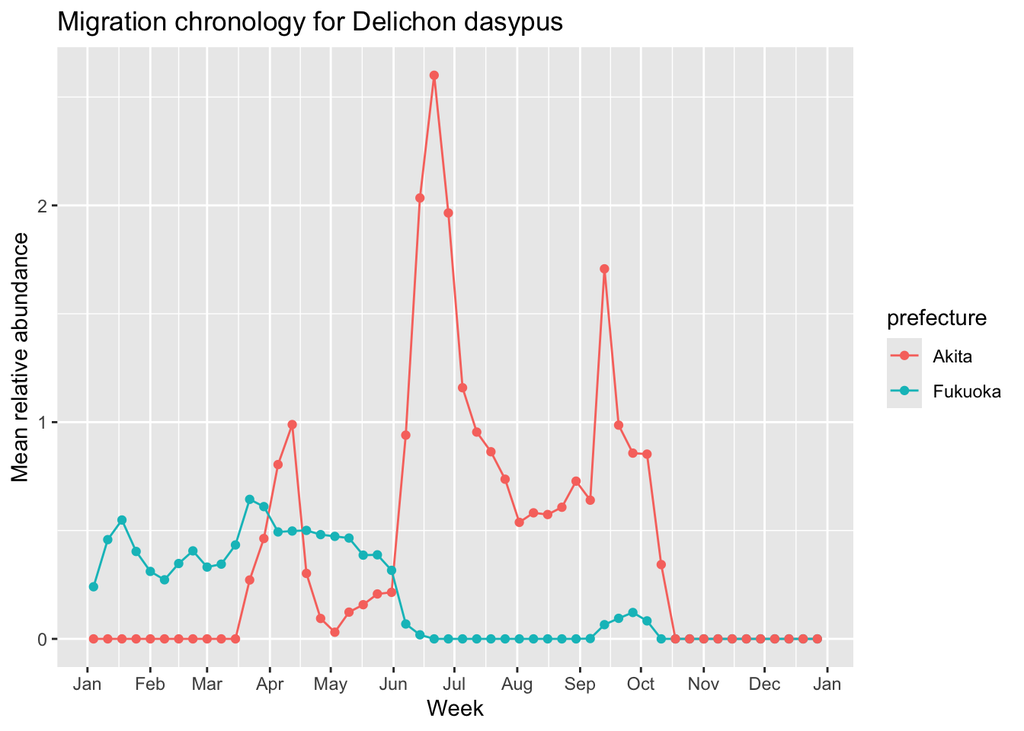

```r
ggplot(chronology) +
  aes(x = week, y = abd, color = prefecture) +
  geom_line() +
  geom_point() +
  scale_x_date(date_labels = "%b", date_breaks = "1 month") +
  labs(x = "Week",
       y = "Mean relative abundance",
       title = "Migration chronology for Delichon dasypus")
```